# eda

To proceed with the exploratory data analysis (EDA), I'll outline the following steps:

- Data Cleaning
- Descriptive Statistics
- Categorical Analysis
- Anomaly Detection
- Trend Analysis and Projection
- Visualizations

## Data Cleaning

|  | MONTH | SERVICE_CATEGORY | CLAIM_SPECIALTY | PAYER | PAID_AMOUNT |
| --- | --- | --- | --- | --- | --- |
| 0 | 201801 | AncillaryFFS | NaN | Payer F | 4281 |
| 1 | 201801 | AncillaryFFS | NaN | Payer H | 2221 |
| 2 | 201801 | AncillaryFFS | NaN | Payer O | 3937 |
| 3 | 201801 | AncillaryFFS | NaN | Payer W | 268 |
| 4 | 201801 | AncillaryFFS | ACH | Payer W | 151 |

There are no missing values in the MONTH, SERVICE_CATEGORY, PAYER, and PAID_AMOUNT columns.

There are 251 missing values in the CLAIM_SPECIALTY column. Given that this column represents a classification of the medical service, it might be reasonable to replace missing values with a placeholder like "Unknown" or "Not Specified".

```
MONTH                 0
SERVICE_CATEGORY      0
CLAIM_SPECIALTY     251
PAYER                 0
PAID_AMOUNT           0
dtype: int64
```

```
count    5.215200e+04
mean     3.708707e+03
std      3.449842e+04
min     -4.223000e+04
25%      1.940000e+02
50%      5.860000e+02
75%      1.465000e+03
max      2.268611e+06
Name: PAID_AMOUNT, dtype: float64
```

From the descriptive statistics for the PAID_AMOUNT column:

- The average (mean) claim amount is approximately $3,708.71.
- The standard deviation is $34,498.42, which indicates a wide spread in the claim amounts.
- The minimum claim amount is -$42,230.00, which indicates that there are some negative claims. These could represent refunds or adjustments.
- The 25th percentile claim amount is $194.00.
- The median (50th percentile) claim amount is $586.00.
- The 75th percentile claim amount is $1,465.00.
- The maximum claim amount is a substantial $2,268,611.00.

Next, let's aggregate the data by month and visualize the total claim amounts over time to examine the monthly trends in the total PAID_AMOUNT.

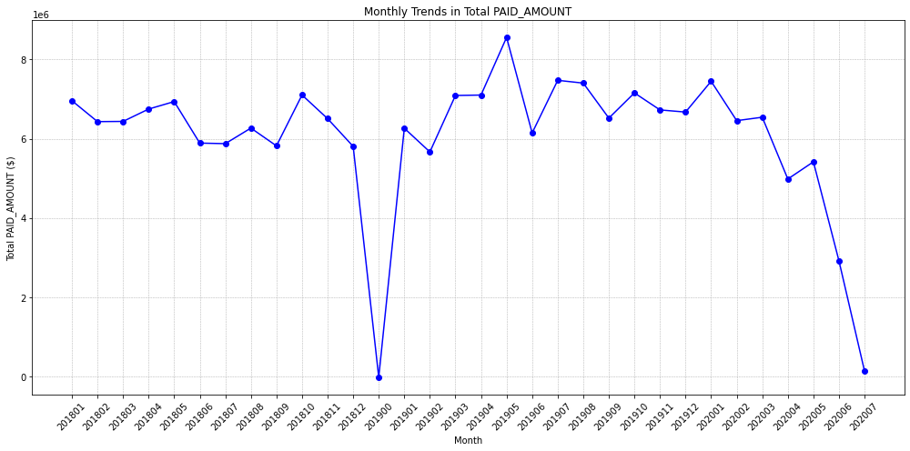

On the "Month" axis, we have invalid data labeled as "201900". Let's remove it from the dataset. Additionally, there's been a sharp decline over the last three months. This is likely a result of the COVID pandemic. We should account for this anomalous decrease when projecting for the next six months.

## Descriptive Statistics

Now, let's re-run the data analysis:

Descriptive Statistics: Provide a summary of the PAID_AMOUNT to understand its distribution.

```
count    5.214100e+04
mean     3.710003e+03
std      3.450187e+04
min     -4.223000e+04
25%      1.940000e+02
50%      5.860000e+02
75%      1.465000e+03
max      2.268611e+06
Name: PAID_AMOUNT, dtype: float64
```

Almost nothing has been changed. The updated descriptive statistics for the PAID_AMOUNT column are as follows:

- The average (mean) claim amount is approximately $3,710.00.
- The standard deviation is $34,501.87, which indicates a wide spread in the claim amounts.
- The minimum claim amount is -$42,230.00, which indicates that there are some negative claims. These could represent refunds or adjustments.
- The 25th percentile claim amount is $194.00.
- The median (50th percentile) claim amount is $586.00.
- The 75th percentile claim amount is $1,465.00.
- The maximum claim amount is a substantial $2,268,611.00.

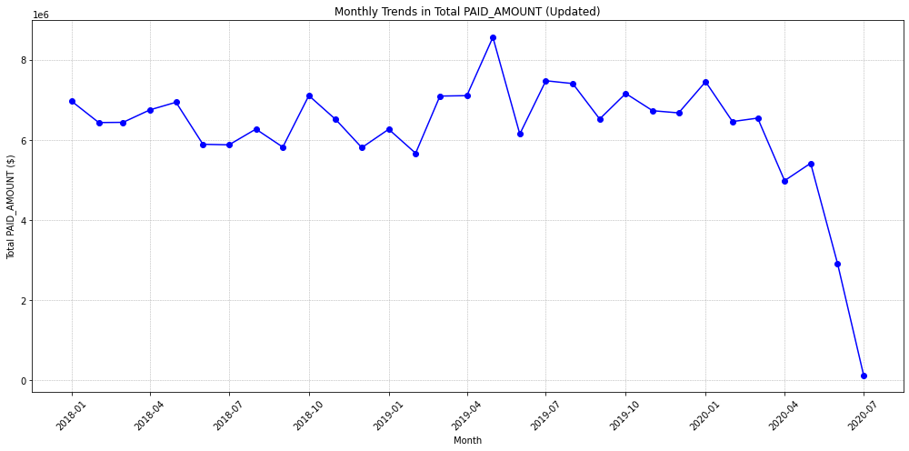

## Categorical Analysis

The visualizations provide insights into the distribution of claims across different categories:

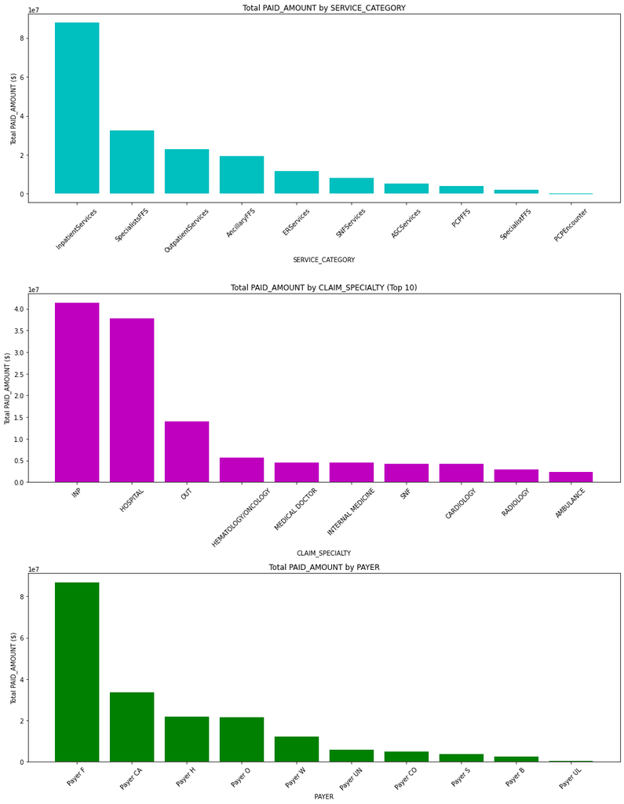

**Total PAID_AMOUNT by SERVICE_CATEGORY:**  
The distribution across service categories is evident, with some categories having significantly higher claim amounts than others.

**Total PAID_AMOUNT by CLAIM_SPECIALTY (Top 10):**  
The visualization focuses on the top 10 specialties based on total paid amounts. A few specialties stand out with considerably higher claim amounts.

**Total PAID_AMOUNT by PAYER:**  
The distribution of total claim amounts across different payers (insurance companies) shows variability, with some payers having much higher totals than others.

## Anomaly detection

Based on the statistical approach (looking for values in the PAID_AMOUNT column that fall outside three standard deviations from the mean), we've detected 237 anomalies. These anomalies represent unusually high or low claim amounts compared to the majority of the data.

```
237
```

The boxplot for PAID_AMOUNT provides a visual representation of the distribution of claim amounts:

- The majority of the data (represented by the box) lies within a relatively small range.
- There are numerous data points (outliers) that fall outside the interquartile range, especially on the higher end of the claim amounts.

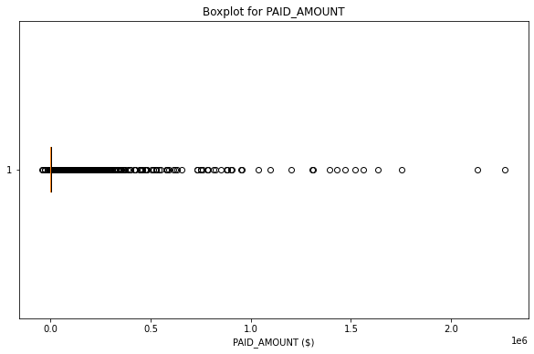

The plot displays the monthly trends in the total PAID_AMOUNT with anomalies highlighted in red.

Observations:

- The anomalies, represented by red 'x' markers, show significant deviations from the overall monthly trend.
- These anomalies are scattered across various months and represent exceptionally high claim amounts.

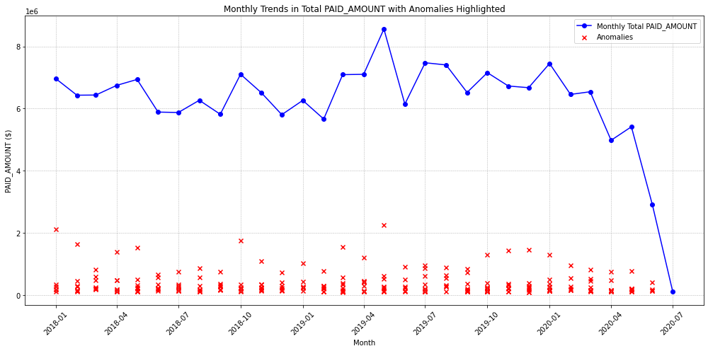

## Trends and projections for the upcoming 6 months.

The plot displays the monthly trends in the total PAID_AMOUNT alongside a 12-month moving average.

There has been a significant decline over the past three months, likely due to the COVID pandemic. I've removed the data from these months because they exhibit anomalous behavior, making them unsuitable for generating projections and establishing trends.

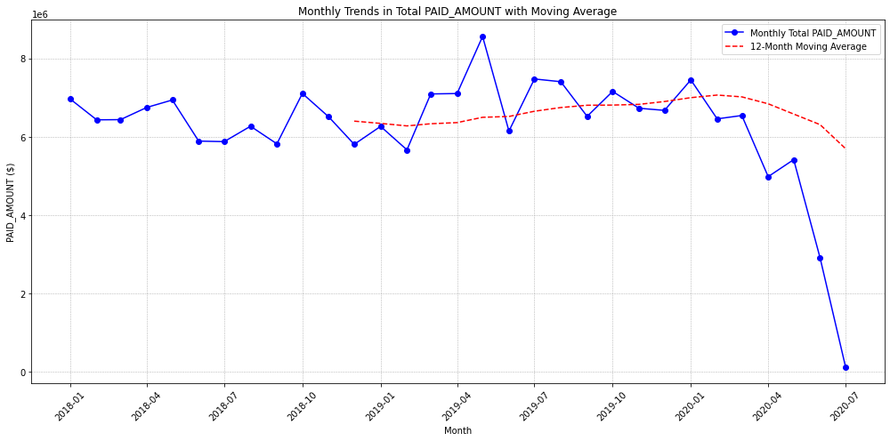

The plot displays the monthly trends in the total PAID_AMOUNT alongside a 12-month moving average for the filtered data (up to March 2020):

**Monthly Total PAID_AMOUNT:**

- The claim amounts fluctuate over time, with some peaks and troughs evident.
- We can observe an increasing trend in the early months, followed by some decrease, and then another increasing trend.

**12-Month Moving Average:**

- The red dashed line represents the 12-month moving average, which helps in smoothing out short-term fluctuations and reveals longer-term trends.
- The moving average suggests a generally increasing trend in the claim amounts over the years, with some periods of relative stability.

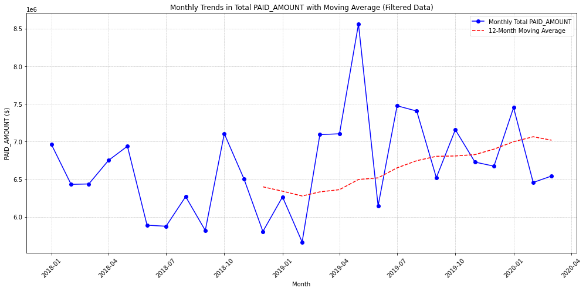

The plot displays the monthly total PAID_AMOUNT broken down by year for the filtered data (up to March 2020):

**Yearly Variation:**

- The magnitude of claim amounts seems to differ from one year to the next. For instance, the peaks in 2019 appear higher than those in 2018.
- This indicates that while there's a seasonal pattern, the overall volume of claims may be increasing year over year.

In summary, for the filtered dataset (up to March 2020), there's both a seasonal pattern within each year and an overall upward trend over the years. This insight can be beneficial for planning and forecasting purposes.

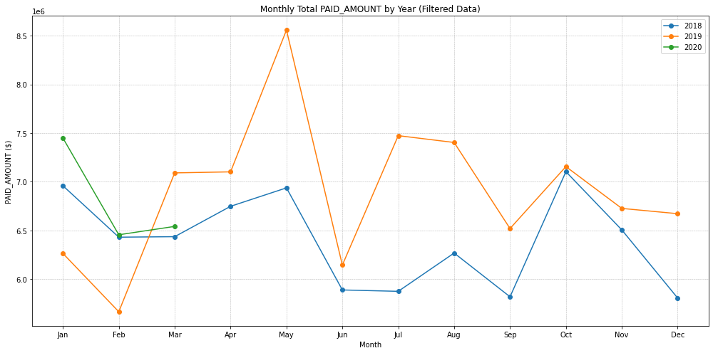

## Six months projection

To forecast the PAID_AMOUNT for the upcoming 6 months, various time series forecasting methods can be employed. One of the most widely used methods for time series forecasting is the ARIMA model (Autoregressive Integrated Moving Average). The ARIMA model captures different aspects of the time series data, such as trend, seasonality, and noise, to make predictions.

The ARIMA model has been used to forecast the PAID_AMOUNT for the next 6 months after March 2020. Here are the projections:

April 2020: Approximately $6,601,287

May 2020: Approximately $6,514,233

June 2020: Approximately $6,522,795

July 2020: Approximately $6,626,140

August 2020: Approximately $6,585,591

September 2020: Approximately $6,593,958

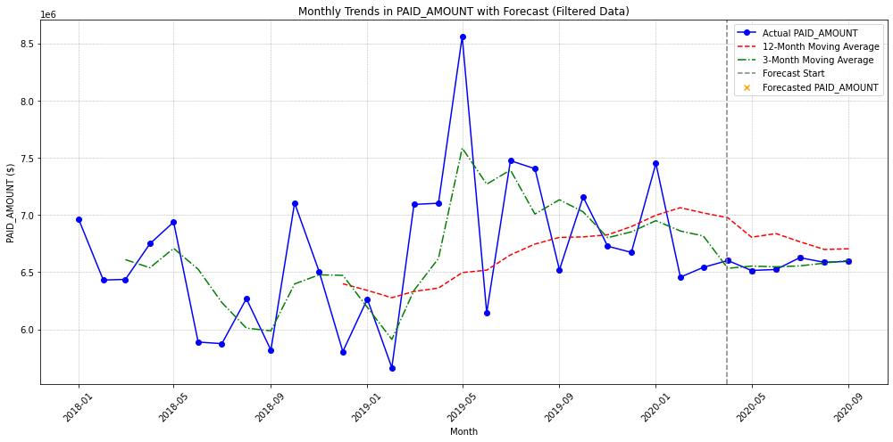